[figure not shown]

# Image Imputation using SVD

Previously, we used SVD (Singular Value Decomposition) for lossy image compression. But could the same approach be adapted to recover an image with missing pixels?

Published on August 18, 2024

```python
import numpy as np
import matplotlib.pyplot as plt
import matplotlib.image as img
from fancyimpute import IterativeSVD, SoftImpute
```

## Preprocessing the Image

I have chosen Lena for this task and manually added noise to the image as green pixels (0,255,0).

```
Image shape:  (256, 256, 3)
```

[figure not shown]

```python
# Load the manually damaged image
image = img.imread('data/lena_noisy.png')
print("Image shape: ", image.shape)
_=plt.imshow(image)
_=plt.title("Noisy image")
```

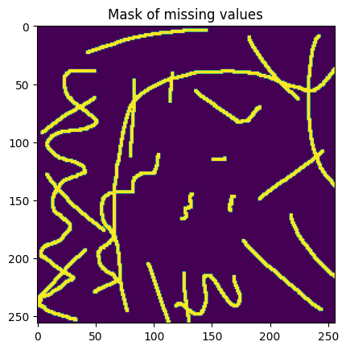

```python
# Extract the green color (which is the missing pixels)
mask = image[:,:,1] > 0.99
image_with_nans = image.copy()
image_with_nans[mask,:] = np.nan

_=plt.imshow(mask)
_=plt.title('Mask of missing values')
```

## Option 1: Imputing the Image Matrix

[In my previous blog post](https://salihmarangoz.github.io/blog/Image-Compression-With-SVD/) I have shown that by decomposing an image matrix into its singular components we can remove the components that have minimal influcence. In a similar fashion, it is possible to get these components while missing values present in the input. After the prediction, we can get the full matrix by multiplying these components. This is a well known method for data imputation in data science.

[figure not shown]

```python
image_r_new = IterativeSVD(min_value=0.0, max_value=1.0, verbose=False).fit_transform(image_with_nans[:,:,0])
image_g_new = IterativeSVD(min_value=0.0, max_value=1.0, verbose=False).fit_transform(image_with_nans[:,:,1])
image_b_new = IterativeSVD(min_value=0.0, max_value=1.0, verbose=False).fit_transform(image_with_nans[:,:,2])

image_new = np.stack([image_r_new, image_g_new, image_b_new], axis=2)

_=plt.imshow(image_new)
_=plt.title('Recovered image by using IterativeSVD directly on the image matrix')
```

Well... It kind of worked but there are many artifacts. I will not dive in to the details of SVD in this post, but will discuss about how it works. Let's solve a toy data imputation problem. We have different movie ratings from different users, however not every user rated every movie.

|  | Movie 1 | Movie 2 | Movie 3 |
| --- | --- | --- | --- |
| User 1 | 5 | ??? | 4 |
| User 2 | 2 | 5 | 5 |
| User 3 | ??? | 3 | 4 |
| User 4 | 1 | ??? | 5 |
| User 5 | 5 | 1 | 5 |

We can solve this problem using SoftImpute, an Expectation-Maximization approach using SVD iteratively. Since there is not enough data it works better than IterativeSVD.

```python
feature_matrix = np.array([[5.0, np.nan, 4.0], [2.0, 5.0, 5.0], [np.nan, 3.0, 4.0], [1.0, np.nan, 5.0], [5.0, 1.0, 5.0]])
feature_matrix_imputed = SoftImpute(min_value=1, max_value=5, verbose=False).fit_transform(feature_matrix)
feature_matrix_imputed
```

```
array([[5.        , 1.05637665, 4.        ],
       [2.        , 5.        , 5.        ],
       [1.61854979, 3.        , 4.        ],
       [1.        , 3.05440431, 5.        ],
       [5.        , 1.        , 5.        ]])
```

It looks pretty good in this example, however it did not work well in the image example.

## Option 2: Imputing the Neighborhood Feature Matrix

I did a quick search on the Internet about this but found nothing. Maybe I am the first who is using like this kind of approach.

So, I thought: How would I fix this image if only a single pixel was missing? As an approach, I would check for the neighbors of the missing pixel, and predict its value with a another pixel with similar neighbors. This idea sounded cool so I just had to adapt the data for it. Let's just modify the table above with this approach:

| Target Pixel | Neighbor 1 | Neighbor 2 |
| --- | --- | --- |
| 5 | ??? | 4 |
| 2 | 5 | 5 |
| ??? | 3 | 4 |
| 1 | ??? | 5 |
| 5 | 1 | 5 |

So, the idea is if we can create a matrix like this, after we impute the matrix the first column would be the recovered image.

If you didn't understand this let me explain it in a different way. SVD works in a matrix where each rows represents a sample. So the matrix shape would be (samples*features). But an image is a single sample with all pixel values being its features. So, we need to extract features to make it work with SVD as intended.

```python
def extract_features(image, neighborhood_size, stride=1):
    rows, cols, _ = image.shape
    half_size = neighborhood_size // 2
    feature_matrix = []

    for i in range(rows):
        for j in range(cols):
            features = [image[i, j]]
            for ii in range(-half_size, half_size + 1):
                for jj in range(-half_size, half_size + 1):
                    if ii == 0 and jj == 0: continue
                    if i + ii*stride >= 0 and i + ii*stride < rows and j + jj*stride >= 0 and j + jj*stride < cols:
                        features.append(image[i + ii*stride, j + jj*stride])
                    else:
                        features.append([np.nan, np.nan, np.nan])
            feature_matrix.append(features)

    return np.array(feature_matrix).reshape(rows*cols, -1).copy()

# Extract the features matrix
features_matrix = extract_features(image_with_nans, 13, 1)
print(features_matrix.shape)
```

```
(65536, 507)
```

```python
# Impute the missing values
features_matrix_imputed = IterativeSVD(min_value=0.0, max_value=1.0).fit_transform(features_matrix)
```

```
[IterativeSVD] Iter 1: observed MAE=0.115912
[IterativeSVD] Iter 2: observed MAE=0.082214
[IterativeSVD] Iter 3: observed MAE=0.056298
[IterativeSVD] Iter 4: observed MAE=0.038711
[IterativeSVD] Iter 5: observed MAE=0.034821
[IterativeSVD] Iter 6: observed MAE=0.034509
[IterativeSVD] Iter 7: observed MAE=0.034389
[IterativeSVD] Iter 8: observed MAE=0.034329
[IterativeSVD] Iter 9: observed MAE=0.034295
[IterativeSVD] Iter 10: observed MAE=0.034272
[IterativeSVD] Iter 11: observed MAE=0.034257
[IterativeSVD] Iter 12: observed MAE=0.034245
[IterativeSVD] Iter 13: observed MAE=0.034236
```

[figure not shown]

```python
# The first column holds the pixel values of the recovered image
imputed_image = features_matrix_imputed[:,:3].reshape(image.shape)

# Side by side comparison
original_image = img.imread('data/lena.png')
plt.figure(figsize=(15, 7))
plt.subplot(1, 3, 1)
plt.imshow(original_image)
plt.title('Original Image')
plt.subplot(1, 3, 2)
plt.imshow(imputed_image)
plt.title('Imputed Image')
plt.subplot(1, 3, 3)
plt.imshow(image)
plt.title('Noisy Image')
plt.tight_layout()
```

## Comparison with Image Interpolation Methods

Actually my first approach wouldn't be using SVD for solving this type of problem. I was just forcing SVD to impute an image data by providing neighborhood features. However interpolation methods are specialized in this area. To my eyes (qualitative evaluation), our SVD approach looks better than the nearest interpolation, however linear and cubic interpolation provided better results.

[figure not shown]

```python
from scipy.interpolate import griddata

def interpolate_image_single_channel(image, missing_mask, method):
    rows, cols = image.shape
    points = []
    values = []

    for i in range(rows):
        for j in range(cols):
            if missing_mask[i, j]:
                continue
            points.append([i, j])
            values.append(image[i, j])

    points = np.array(points)
    values = np.array(values)

    grid_x, grid_y = np.mgrid[0:rows, 0:cols]
    interpolated_grid = griddata(points, values, (grid_x, grid_y), method=method)
    return np.clip(interpolated_grid, 0, 1)

def interpolate_image(image, missing_mask, method):
    image_r = interpolate_image_single_channel(image[:,:,0], missing_mask, method)
    image_g = interpolate_image_single_channel(image[:,:,1], missing_mask, method)
    image_b = interpolate_image_single_channel(image[:,:,2], missing_mask, method)
    return np.stack([image_r, image_g, image_b], axis=2)


# Interpolate the missing values using linear interpolation
interpolated_image_nearest = interpolate_image(image_with_nans, mask, 'nearest')
interpolated_image_linear = interpolate_image(image_with_nans, mask, 'linear')
interpolated_image_cubic = interpolate_image(image_with_nans, mask, 'cubic')

# 2x2 comparison
plt.figure(figsize=(14, 14))
plt.subplot(2, 2, 1)
plt.imshow(imputed_image)
plt.title('SVD Imputation')
plt.subplot(2, 2, 2)
plt.imshow(interpolated_image_nearest)
plt.title('Nearest Interpolation')
plt.subplot(2, 2, 3)
plt.imshow(interpolated_image_linear)
plt.title('Linear Interpolation')
plt.subplot(2, 2, 4)
plt.imshow(interpolated_image_cubic)
plt.title('Cubic Interpolation')
plt.tight_layout()
```

## Noise Challenge

Let's push this method to its limits!

```python
def recover_noisy_lena(noise_amount):
  # Add some noise to make it worse...
  image = img.imread('data/lena_noisy.png')
  noise_mask = np.random.rand(image.shape[0], image.shape[1]) < noise_amount
  image[noise_mask,:] = np.array([0, 1, 0])

  # Extract the green color (which is the missing pixels)
  mask = image[:,:,1] > 0.99
  image_with_nans = image.copy()
  image_with_nans[mask,:] = np.nan

  features_matrix = extract_features(image_with_nans, 13, 1)

  # Impute the missing values
  features_matrix_imputed = IterativeSVD(min_value=0.0, max_value=1.0, verbose=False).fit_transform(features_matrix)

  # The first column holds the pixel values of the recovered image
  imputed_image = features_matrix_imputed[:,:3].reshape(image.shape)

  # Side by side comparison
  original_image = img.imread('data/lena.png')
  plt.figure(figsize=(15, 7))
  plt.subplot(1, 3, 1)
  plt.imshow(original_image)
  plt.title('Original Image')
  plt.subplot(1, 3, 2)
  plt.imshow(imputed_image)
  plt.title('Imputed Image')
  plt.subplot(1, 3, 3)
  plt.imshow(image)
  plt.title('Noisy Image')
  plt.tight_layout()
```

### 10% Noise

[figure not shown]

```python
recover_noisy_lena(0.1)
```

### 25% Noise

[figure not shown]

```python
recover_noisy_lena(0.25)
```

### 50% Noise

[figure not shown]

```python
recover_noisy_lena(0.5)
```

### 75% Noise

[figure not shown]

```python
recover_noisy_lena(0.75)
```

### 90% Noise

[figure not shown]

```python
recover_noisy_lena(0.90)
```

## 50% Noise + Comparison with Cubic Interpolation

[figure not shown]

```python
# Sorry for the copy-paste :(
image = img.imread('data/lena_noisy.png')
noise_mask = np.random.rand(image.shape[0], image.shape[1]) < 0.5
image[noise_mask,:] = np.array([0, 1, 0])
mask = image[:,:,1] > 0.99
image_with_nans = image.copy()
image_with_nans[mask,:] = np.nan
features_matrix = extract_features(image_with_nans, 13, 1)
features_matrix_imputed = IterativeSVD(min_value=0.0, max_value=1.0, verbose=False).fit_transform(features_matrix)
imputed_image = features_matrix_imputed[:,:3].reshape(image.shape)
interpolated_image = interpolate_image(image_with_nans, mask, 'cubic')

# Side by side comparison
original_image = img.imread('data/lena.png')
plt.figure(figsize=(20, 7))
plt.subplot(1, 4, 1)
plt.imshow(original_image)
plt.title('Original Image')
plt.subplot(1, 4, 2)
plt.imshow(imputed_image)
plt.title('SVD Imputation')
plt.subplot(1, 4, 3)
plt.imshow(interpolated_image)
plt.title('Cubic Interpolation')
plt.subplot(1, 4, 4)
plt.imshow(image)
plt.title('Noisy Image')
plt.tight_layout()
```

## Closing Thoughts

I think the SVD approach worked pretty well for images. Although we observed that image interpolation works better. For sure there are better approaches for recovering incomplete images, but here in this blog post we applied data imputation succesfully to images and it is quite resistant to noise. There would be better deep learning based methods but those models usually carry prior information which is very important. For example, if I would remove an eye of Lena in the image, our approach would not be able to recover it. However a deep learning based method may be able to recover the eye since it knows human have two eyes.

Does it look exciting? Maybe it would work better in another color space such as HSV? Maybe if we can provide rotation-invariant features it can repeat the patterns on the image. Experiment your ideas and leave a comment if you liked the post :)